# Race Distribution in Jail from 2009 to 2018

Yuhan Zhang

2/25/2022

# Introduction

Racism becomes a hot topic after the death of Floyd. For most people, black people sometimes mean low education level and violence, and because of this stereotype for black, people may assume that most prisoners are black, which is totally a wrong image for prisoners.

According to the data set collected by [Vera Institute](https://www.vera.org/), the overall percentage of black prisoners is 34%, while the percentage of white is around 37.98%, which is almost the same, while the proportion of black people in prison is a little bit lower than the one for white people. In 2018, which is the most recent year that has data, the proportion of black prisoners is 33.58%, while the white take around 46.95%. For other races, like AAPI and native, their proportion in prisoner is lower than black and white, which is only around 2.63%.

## Change over Time

When we think about black people which are in prison, we often think that their population in prison is continuously increasing, but this is not a correct statement. The graph below shows the change in black people, white people, and people with other races which are in prison, which clearly shows that the number of white prisoners is the one that increase over the time, and the population of black is decreasing for the past ten years.

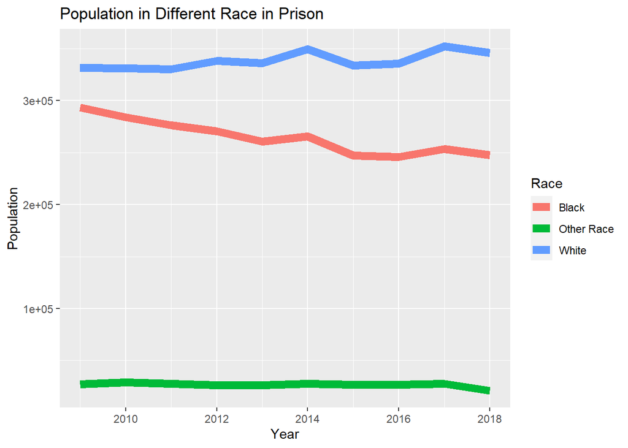

## Comparison between Races in Each Year

So how is their difference for each year? The graph below shows the numbers of different races for each year in a grouped bar chart, which also shows the difference between black prisoners and white prisoners. The number of difference between them is a shocking one, which reaches 98515 in 2018.

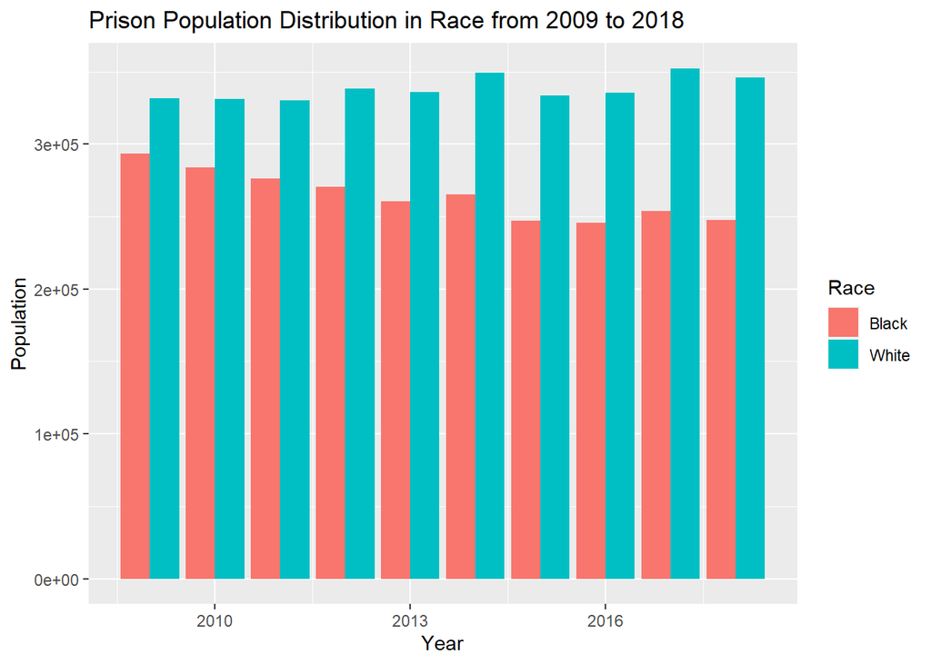

## Minor Races Proportion across US

The map below shows the proportion of colored people in prison across the US. From the map, we can clearly see that the states in southeast has a higher proportion of minor races among prisoners, while in the west part of US, the rate is much lower. The reason of this phenomenon may that for states in west with higher level of economy, they also have higher education level and their mind is more open than those with worse economy. Due to the reason above, black people would have a better life in states with a more open mind about race and gender.

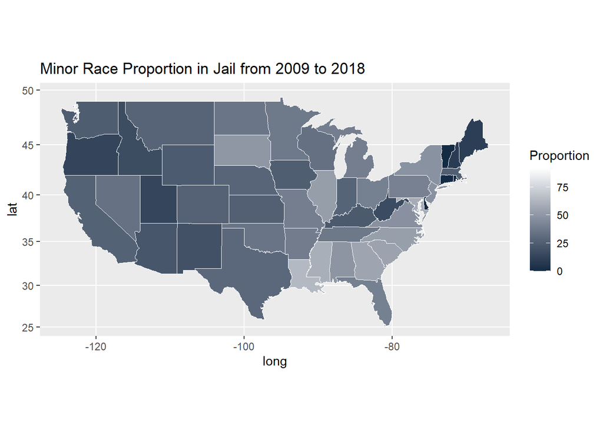